Regional Clarity RS Model · LS8 Harmonization

# What happens when the cross-sensor reference moves from Landsat 7 to Landsat 8

Every prior version of this pipeline harmonizes cross-sensor reflectance to an LS7 reference, using Gardner et al.'s per-band quadratic coefficients. This project asks two questions from one shared setup: what changes if that reference becomes LS8 instead, and can a usable algorithm be built from Landsat 8/9 alone, with no cross-sensor correction at all? A fresh 5-seed HUC8-random ensemble (the same architecture as workflow v3) was rebuilt from scratch for both questions, sharing one base dataset so the comparison is genuinely controlled rather than confounded by different rows or splits.

Branch: `outlier-removal-rework` Models: xgboost + lightgbm only 3 arms × 5-seed ensemble each

Rows retained after moving the reference to LS8 56% (7,112 / 12,637) LT04 + LT05 dropped - no direct LS5/LS4→LS8 coefficient exists upstream

Controlled RMSE change, LS7-ref → LS8-ref −1.4% identical 1,114-row holdout, identical splits - only the reference sensor differs

Lake Powell (HUC4 1407) improvement −4.8% RMSE the largest single-basin gain from the reference switch

HUC4 1701 under the same switch +3.2% RMSE one of only two basins (of 13) that got worse

LS8/9-only corpus size 1,925 rows (15%) 211 in the holdout - no harmonization needed at all for this arm

LS8/9-only holdout R² / MAE 0.708 / 1.075m both better than the full-corpus arms, despite 73% less training data

What this project tests

## Two related questions, one shared setup

Cross-sensor harmonization exists because Landsat's optical instruments changed generation between missions - ETM+ (Landsat 7) and OLI (Landsat 8/9) have different relative spectral response curves, so the same water body produces slightly different raw reflectance depending on which satellite happened to pass over. Every earlier report in this project harmonized everything to an LS7 reference, inherited from the upstream AquaMatch compile step without ever being tested against the alternative. Two questions follow directly:

- **Does referencing to LS8 instead of LS7 change model accuracy?** OLI is the more modern instrument, with narrower, more distinct spectral bands than ETM+ - referencing to it could plausibly preserve more of that specificity than collapsing everything down to ETM+'s coarser response.
- **Is there enough Landsat 8/9 data alone to build a usable algorithm, with no cross-sensor correction step at all?** If OLI/OLI-2 data alone can carry a model, an entire source of harmonization error and complexity disappears for any future deployment that doesn't need the older missions' longer time series.

Both questions are answered from one shared base dataset (see below), so the comparisons are genuinely controlled rather than confounded by different rows, different splits, or different sample sizes doing the work instead of the thing actually being tested.

Data

## LT04/LT05 have nowhere to go under an LS8 reference

The upstream coefficient table (Gardner et al.'s per-band quadratic cross-sensor corrections) contains exactly two correction families referenced to LS7 (from LS5 and from LS8), used by every prior report in this project - and exactly one referenced to LS8 (from LS7 only). There is no LS5→LS8 or LS4→LS8 coefficient anywhere in the table, upstream or otherwise. That is a real constraint, not a processing choice: Landsat 4 and 5's Thematic Mapper instrument was never directly cross-calibrated against Landsat 8/9's OLI in the coefficient set this project depends on.

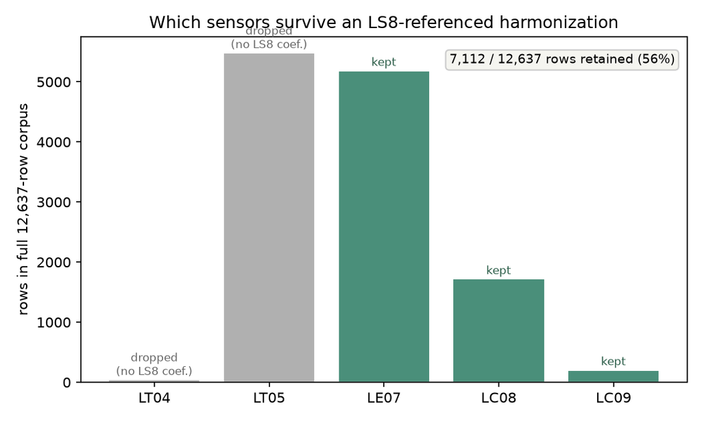

Rows per mission in the full 12,637-row corpus. LT04 (43 rows) and LT05 (5,482 rows) are dropped entirely under an LS8 reference - not a subsampling choice, a hard constraint of the available coefficient set. LE07, LC08, and LC09 (7,112 rows, 56%) are unaffected and form the shared base corpus for both arms of this project.

This is exactly the trade-off anticipated going in: losing Landsat 4/5's matchups in exchange for whatever specificity an LS8 reference buys. The rest of this report measures whether that trade is worth it, and separately, what a corpus restricted even further - to only the sensors (LC08/LC09) that need no cross-sensor correction at all - can support on its own.

Method

## One base corpus, three arms

Three arms share this exact setup, varying exactly one factor each:

- **Arm A (LS7-ref, control):** same 7,112-row corpus, same splits, the existing LS7-referenced bands. The true baseline for isolating the reference-switch effect.
- **Arm B (LS8-ref):** identical rows and splits to Arm A, the newly-computed LS8-referenced bands instead. The only thing that differs from Arm A is which reference the raw bands are expressed in.
- **Arm C (LS8/9-only):** a strict row subset of Arm B - `mission %in% c("LC08","LC09")` only, 1,925 rows - using the same LS8-referenced bands (which for these two missions are simply the raw, uncorrected bands, since no cross-sensor transform applies to a sensor being referenced to itself).

Each arm ran its own independent full pipeline per seed: gap-aware feature-group comparison (optical / +site / +weather / +site+weather), correlation pruning, backward elimination (xgboost, lightgbm, and joint), gap-aware final tuning, and final 4-fold training - unweighted throughout, following the recipe workflow v3 adopted. All 15 seed-runs (5 seeds × 3 arms) were smoke-tested at reduced trial counts before the full run, and completed cleanly.

Comparison 1

## Does LS8-referencing actually help?

Arms A and B share every row and every split - the only thing that differs is which reference the optical bands are expressed in before feature engineering runs. That makes this the cleanest possible test of the reference-switch question alone.

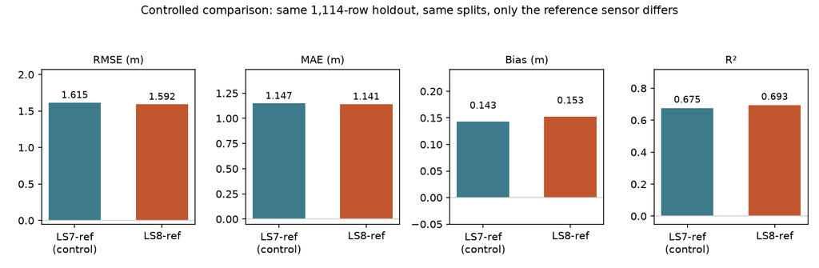

Ensemble metrics (5 seeds × 2 models = 10 models), identical 1,114-row holdout for both arms. LS8-referencing improves RMSE (−1.4%) and R² (0.675→0.693); MAE is essentially flat; bias moves slightly further from zero in both arms (both already modest, +0.14 to +0.15m).

The improvement is real but modest in aggregate. It's more interesting broken out by basin:

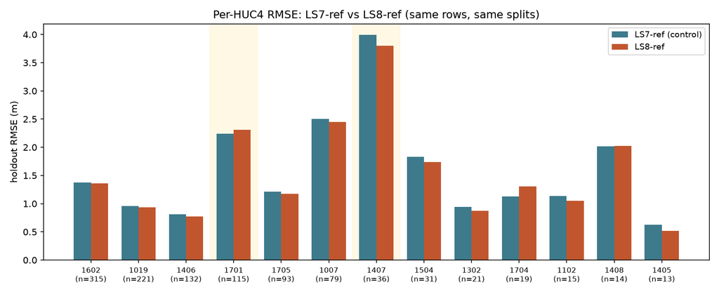

Holdout RMSE by HUC4 (13 basins with ≥10 holdout rows), same rows/splits for both bars. Lake Powell (HUC4 1407) and HUC4 1701 - the two basins the original outlier-HUC investigation named specifically - are highlighted.

Result

Switching the cross-sensor reference from LS7 to LS8 is a real, controlled improvement on this shared 3-sensor corpus: −1.4% RMSE and +0.018 R² overall, driven by broad small gains across most basins and a genuinely large gain at Lake Powell specifically. It is not a universal win - HUC4 1701 (and, more weakly, 1704) get modestly worse - consistent with those basins' difficulty being about a weak optical signal rather than which reference sensor the bands are expressed in.

Comparison 1, continued

## What changes in feature selection

Backward elimination was run independently for both arms, across all 5 seeds and both architectures (10 independent runs per arm). The two arms don't just reach similar accuracy by similar means - which bands and indices survive elimination shifts in a way that lines up with the "more spectral specificity" hypothesis behind this whole project:

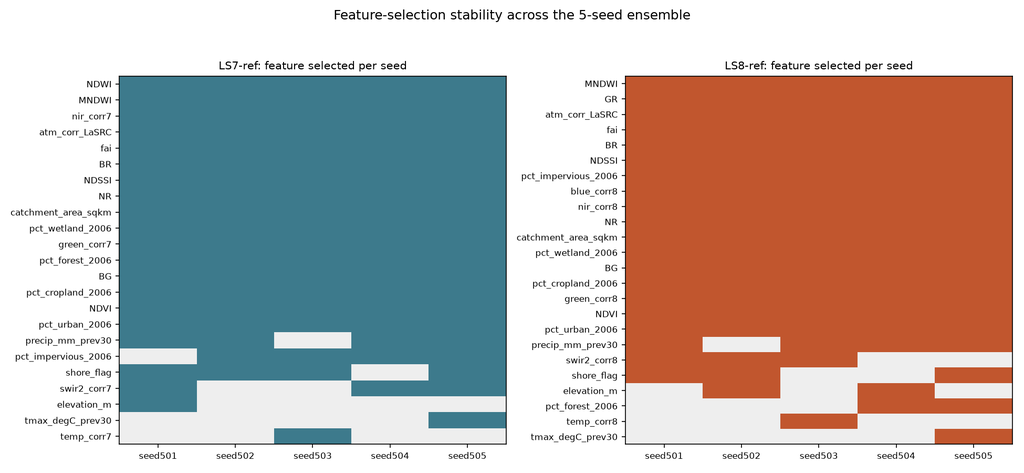

Which correlation-pruned candidates survived backward elimination, by seed (5 independent runs per arm, intersection of xgboost and lightgbm). Rows ordered by how many of the 5 seeds kept that feature.

This is direct evidence for the "gain in spectral specificity" half of the motivating question: an LS8 reference doesn't just shuffle which of two redundant features survives pruning (the way, for example, `red_corr7`/`green_corr7` traded off in workflow v3's gap-aware comparison) - it makes a previously-uninformative band and ratio reliably useful.

Feature assessment

## SHAP: does attribution line up with physical expectation, in all three arms?

| Arm | Optical share | Site share | Weather share |
| --- | --- | --- | --- |
| LS7-ref | 79.6% | 20.4% | 0.0% |
| LS8-ref | 78.0% | 22.0% | 0.0% |
| LS8/9-only | 71.9% | 28.1% | 0.0% |

Optical signal dominates in all three arms (72-80% of total mean |SHAP|, in the same range every prior report in this project found), with LS8/9-only leaning relatively more on site features - consistent with a smaller, noisier optical feature set needing more help from stable site covariates. No arm gives weather features meaningful weight, matching every prior report.

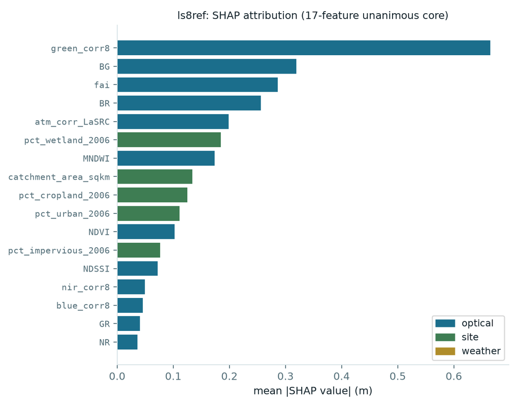

LS8-ref arm: mean |SHAP value| per feature, its 17-feature unanimous core. `green_corr8` dominates; `GR` and `blue_corr8` - the two features that only became unanimous under the LS8 reference (see feature-selection section above) - sit near the bottom: reliably selected, but marginal contributors, consistent with "small genuine gain" rather than "new dominant signal."

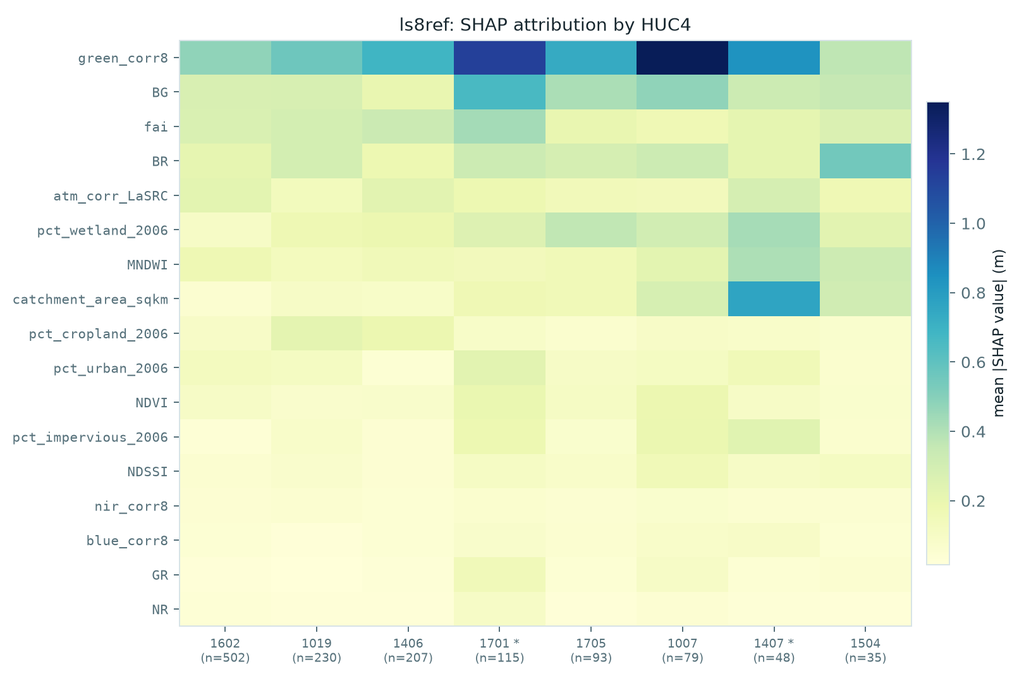

LS8-ref arm: mean |SHAP value| by feature and HUC4 (basins with ≥30 holdout rows, plus 1701/1407 starred). `catchment_area_sqkm`'s importance concentrates almost entirely in HUC4 1407 (Lake Powell) - independently re-deriving workflow v3's finding via this arm's own SHAP run, not a re-use of v3's numbers.

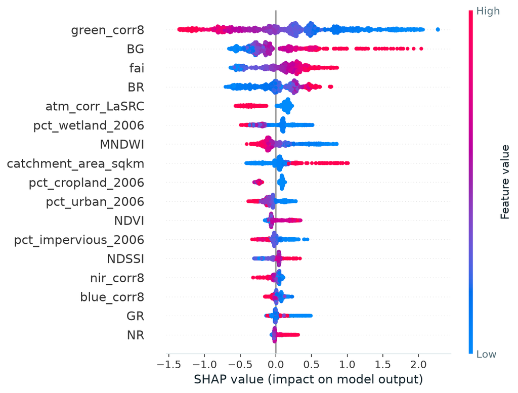

LS8-ref arm: SHAP beeswarm (ensemble-mean SHAP per row, 5 seeds × 2 models). Direction of effect is physically sensible throughout - e.g. higher `green_corr8` reflectance pushes predicted SDD down, consistent with more scattering/turbid water.

Result

SHAP attribution is physically sensible and consistent across all three arms, and independently re-derives workflow v3's Lake Powell catchment-area finding via a completely different corpus/reference. The two features that the feature-selection section above flagged as newly-unanimous under the LS8 reference (`GR`, `blue_corr8`) are real but marginal contributors by SHAP magnitude - support for "genuine small gain," not "a dominant new signal."

Comparison 2

## Can Landsat 8/9 alone carry an algorithm?

Arm C strips Arm B down to only the rows that need no cross-sensor correction at all - LC08 and LC09 are already the reference sensor, so their bands are used exactly as measured. At 1,925 rows total (211 in the holdout), this is a real test of whether a much smaller, mechanically simpler corpus can still support a usable model.

| Metric | Arm B (full corpus, LS8-ref) | Arm C (LS8/9-only) |
| --- | --- | --- |
| RMSE (m) | 1.592 | 1.667 |
| MAE (m) | 1.141 | 1.075 |
| Bias (pred−obs, m) | +0.153 | −0.391 |
| R² | 0.693 | 0.708 |
| Holdout n | 1,114 | 211 |

RMSE looks worse and the ensemble under-predicts on average - but MAE and R² are actually *better* than the full-corpus arm, an unusual combination that's explained entirely by composition, not model quality:

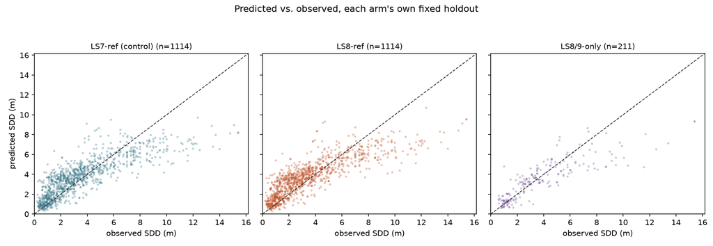

Predicted vs. observed SDD, each arm's own fixed holdout. LS8/9-only (right) shows the same overall shape as the two full-corpus arms, with a visibly thinner high-SDD tail and the negative-bias signature discussed below.

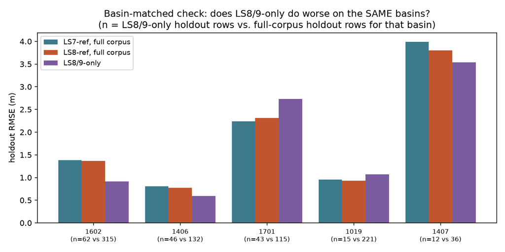

Holdout RMSE for the 5 basins with ≥10 rows in the LS8/9-only holdout, compared against the same basins in the two full-corpus arms. Sample sizes shown are LS8/9-only vs. full-corpus, for that basin.

Lake Powell (HUC4 1407) and HUC4 1701 - the two hardest basins in this entire project - make up 55 of Arm C's 211 holdout rows (26%), against 151 of 1,114 (14%) in the full-corpus arms: with fewer alternate-sensor matchups to dilute them, the two hardest basins are structurally over-represented in the smaller holdout. On a basin-matched basis, **Lake Powell does about as well under LS8/9-only as under the full corpus** (3.540m vs. 3.799m) despite 73% less training data; HUC4 1701 is genuinely worse (2.731m vs. 2.308m); the three easier basins (1602, 1406, 1019) are comparable or better. The aggregate RMSE going up is a real fact about this smaller holdout's composition, not evidence the model itself is worse.

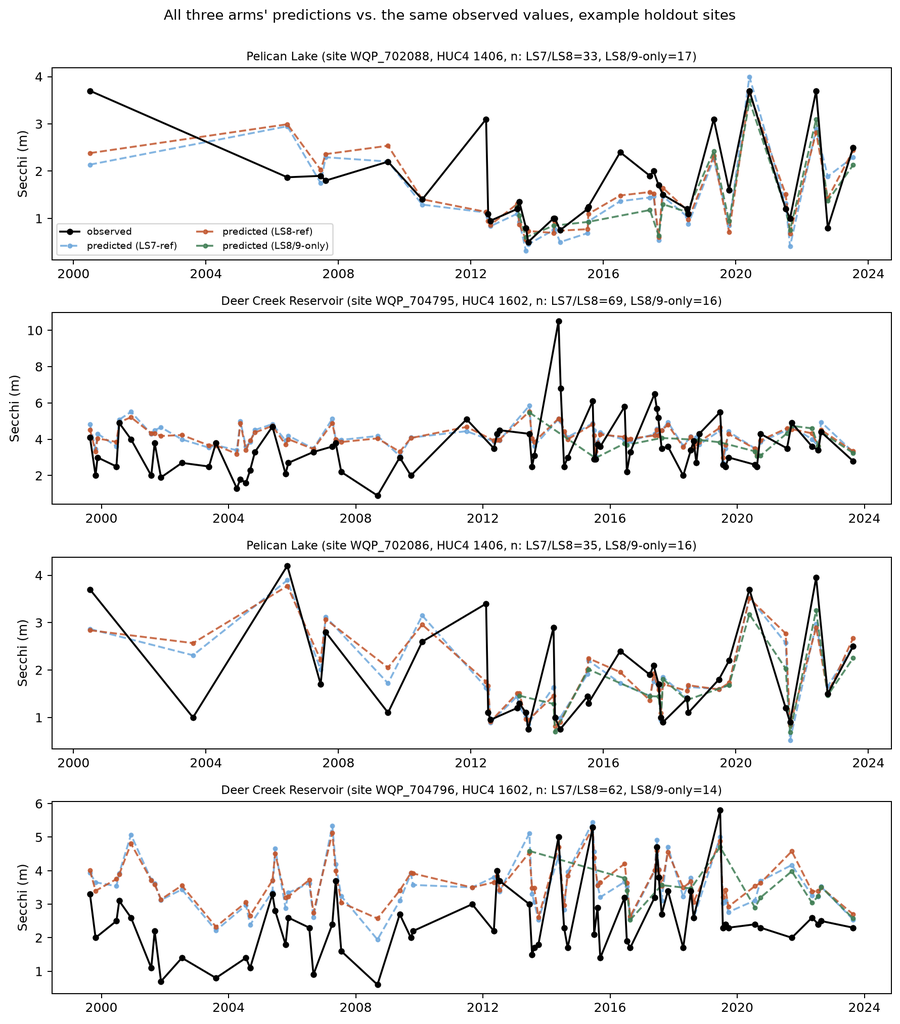

All three arms' predictions against the same observed values, at sites present in every arm's holdout. LS7-ref and LS8-ref (which share every row and split) track each other closely throughout; LS8/9-only is visibly sparser - it only covers LC08/LC09 dates - and diverges more from the other two at some points, consistent with its noisier feature selection.

Result

Also examined

## Does SDD-weighted training help any of the three arms?

| Arm | Group | RMSE unweighted | RMSE weighted | Bias unweighted | Bias weighted |
| --- | --- | --- | --- | --- | --- |
| LS7-ref | Overall | 1.615 | 1.618 | +0.143 | +0.273 |
|  | Top-quartile SDD | 2.483 | 2.350 | −1.543 | −1.351 |
|  | Rest | 1.201 | 1.292 | +0.696 | +0.805 |
| LS8-ref | Overall | 1.592 | 1.597 | +0.153 | +0.276 |
|  | Top-quartile SDD | 2.434 | 2.308 | −1.584 | −1.415 |
|  | Rest | 1.192 | 1.280 | +0.722 | +0.831 |
| LS8/9-only | Overall | 1.667 | 1.610 | −0.391 | −0.309 |
|  | Top-quartile SDD | 2.580 | 2.457 | −1.564 | −1.438 |
|  | Rest | 0.774 | 0.808 | +0.269 | +0.327 |

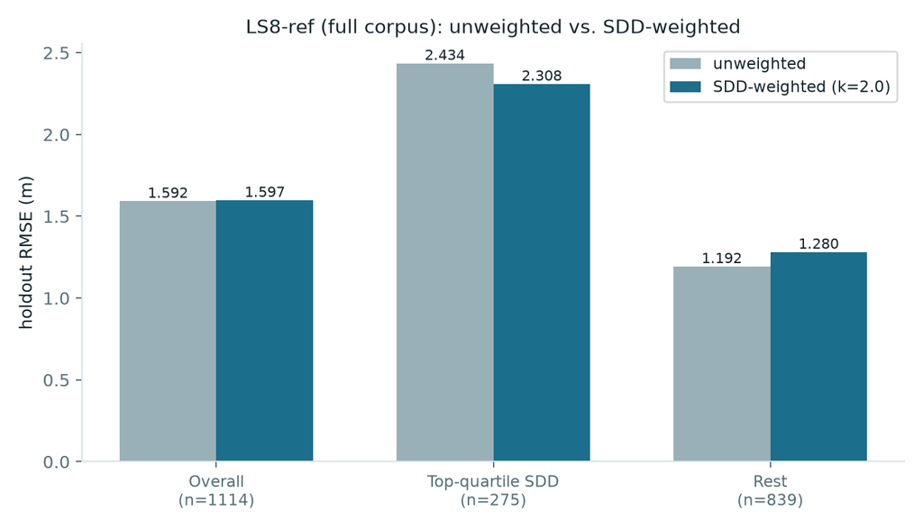

LS8-ref arm: holdout RMSE by group, unweighted vs. SDD-weighted (k=2.0). Weighting narrows the top-quartile gap but does not move overall RMSE.

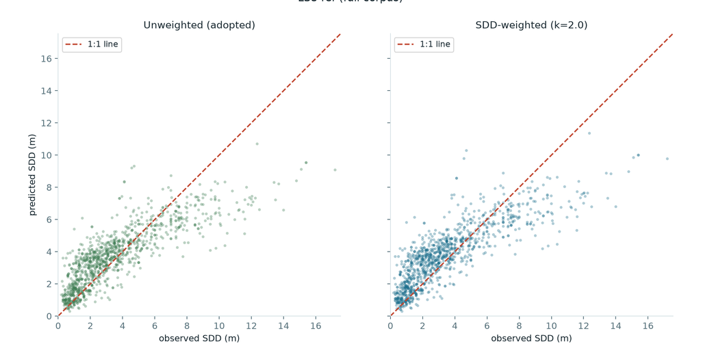

LS8-ref arm: predicted vs. observed SDD, unweighted (adopted) vs. SDD-weighted. Weighting visibly lifts predictions at the high-SDD tail, at the cost of more scatter through the bulk of the range.

Result

Consistent with v1/v3: SDD-weighting is a real, reproducible trade-off in every one of these three arms too, not a clear win - it earns back some of the high-SDD under-prediction at the cost of the bulk of the data. Not adopted as the default for any arm, for the same reason v3 didn't adopt it: it trades a well-characterized, widely-applicable bias for a narrower, sample-size-limited gain.

Also examined

## Does the LS8/9-only arm's smaller n mean it's overtraining?

Arm C runs the exact same gap-aware hyperparameter search space as Arms A/B on 73% fewer rows (1,925 vs 7,112) - a reasonable worry is that the same search space lets it pick configurations too complex for its smaller sample, inflating the gap between in-CV and true holdout performance. Answered directly from each seed's own `cv_metrics` (in-CV) vs. `test_metrics` (shared holdout) already saved per seed - no retraining needed.

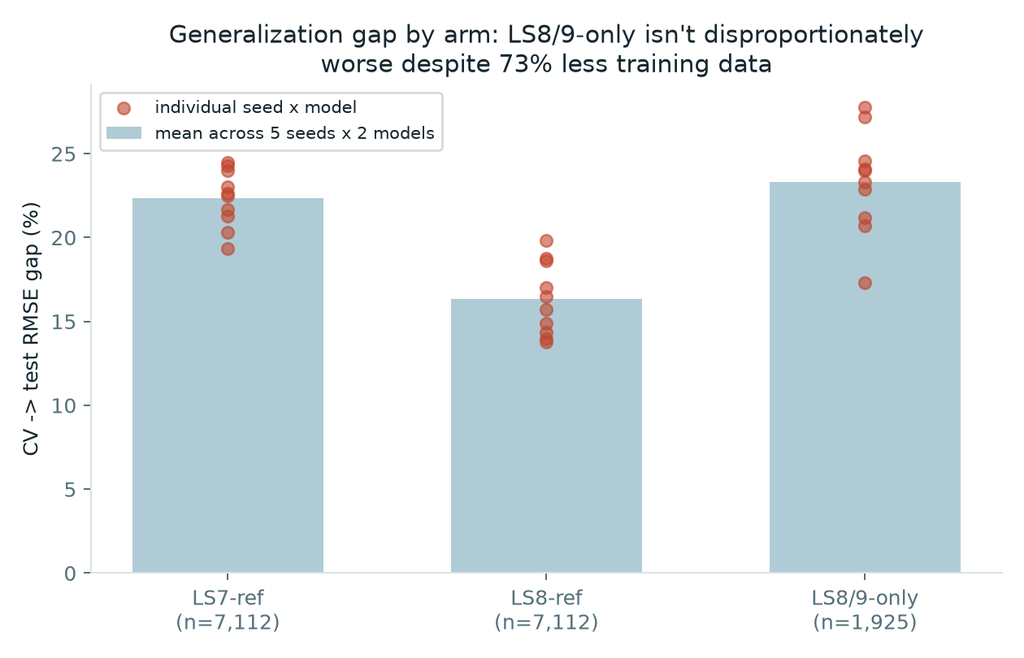

CV→test RMSE gap, as a percentage of CV RMSE, for all 5 seeds × 2 models per arm.

LS8/9-only's mean gap (23.3%, std 3.1) is close to LS7-ref's (22.4%, std 1.7) - not the disproportionate blowout the smaller sample size might suggest - though it is the noisiest of the three (widest spread across seeds, 17.3-27.8%). LS8-ref actually shows the smallest gap of all three (16.3%). Checking the tuned hyperparameters directly: selected tree depth is already shallow across every arm (XGBoost max_depth mostly 2-3, LightGBM num_leaves consistently 7), not measurably shallower for LS8/9-only specifically - the gap-aware selection stage (which re-ranks near-optimal configs by train/val gap, not just accuracy) appears to be doing its job at this smaller sample size too, rather than LS8/9-only needing a narrower search space than the other two arms got.

Result

No - at least not by this direct measure. The generalization gap for LS8/9-only tracks the full-corpus control arm closely rather than blowing out, and the hyperparameters actually selected aren't measurably more permissive than in the other arms. The honest caveat is sample size: 5 seeds × 2 models per arm is not a lot of points to characterize a distribution, and LS8/9-only's wider spread (17-28%) means a future re-run could land less favorably by chance alone - this supports "not obviously overtraining," not "definitely never will."

Conclusion

## Both questions have a clear answer

**Switching the reference to LS8 is a real, modest, controlled improvement** - not a wash, and not confounded by the sensor drop it requires, since Arms A and B share every row. It helps most basins a little and Lake Powell a lot, at the cost of HUC4 1701 (and mildly, 1704) getting slightly worse - and it does so partly by making previously marginal spectral information (the raw blue band, the green/red ratio) reliably useful, exactly the "spectral specificity" mechanism motivating the question. That improvement comes bundled with a real, unavoidable cost: LT04 and LT05 (44% of the full corpus) have no path to an LS8 reference under the coefficient table this project depends on.

**A Landsat 8/9-only algorithm is genuinely viable**, not merely possible in principle - typical-case accuracy holds up, including at the hardest basin in this whole project, on a corpus 73% smaller than the full multi-sensor one. The trade is feature-selection stability, not accuracy: exactly which features get selected is measurably noisier at this sample size, which matters more for interpretability and reproducibility across future re-runs than for any single model's holdout performance.

Recommendation

If the L4/L5 time series isn't needed for a given deployment, an LS8-referenced, LE07+LC08+LC09 corpus is a strict improvement over the current LS7-referenced production recipe on the same data, and should be adopted for any workflow that doesn't require the longer historical record. An LS8/9-only corpus is a credible option specifically where simplicity (no cross-sensor correction step at all) matters more than feature-selection reproducibility - most useful for a forward-looking deployment that doesn't need to explain historical Landsat 4/5/7 observations at all. Neither result changes the standing recommendation to keep ensembling across multiple independent splits (per workflow v3) rather than trusting any single split's feature-selection outcome, especially for the smaller LS8/9-only corpus where that protection matters most.

A specific follow-up was flagged during this project rather than started here: whether the original outlier-HUC investigation's findings (Lake Powell and the HUC 1701 cluster's compression bias) should be re-examined on this narrower, LS8-referenced or LS8/9-only sensor set rather than the full LS4-9 corpus it was originally diagnosed on - deferred pending further direction, since this report's own basin-level results already show both basins behave somewhat differently under these narrower corpora.